“Programs must be written for people to read and only incidentally for machines to execute.” ([Hal Abelson](https://en.wikipedia.org/wiki/Hal_Abelson))

## Getting started with R Statistical Software

**Downloading.** You need to install `R` and `Rstudio`:

1. You can get **R statistical software** on the UCLA mirror [here](http://cran.stat.ucla.edu/). Here is a [direct link](http://cran.stat.ucla.edu/bin/macosx/R-3.5.1.pkg) to “Feather Spray” (R version 3.5.1) for Mac OSX - check first that there does not exist anything more recent. Here is a [direct link](http://cran.stat.ucla.edu/bin/windows/base/R-3.5.1-win.exe) for Windows.
2. I recommend you use a Graphical User Interface (GNU) for R such as **R Studio**. You can get the latest release here: [download here](https://www.rstudio.com/products/rstudio/download/#download).

**Introduction to R.** I recommend [cheatsheets](https://www.rstudio.com/resources/cheatsheets/) to get started on R. Many are available, but the 2 main cheatsheets are:

- A [Base R Cheatsheet](https://www.rstudio.com/wp-content/uploads/2016/05/base-r.pdf).
- An [Advanced R Cheatsheet](https://www.rstudio.com/wp-content/uploads/2016/02/advancedR.pdf).

[Datacamp](https://www.datacamp.com/tracks/learn-statistics-with-r) also has great learning tools for `R`, as well as `Python`.

## R-markdown (Rmd)

`R-markdown` is a great tool for keeping your workflow organized and keeping track of each one of your research projects: you can add very easily, images, regression tables, graphs, etc. Again, cheatsheets are a good way to learn. There are two main cheatsheets:

- A [Beginner’s R-Markdown Cheatsheet](https://www.rstudio.com/wp-content/uploads/2015/02/rmarkdown-cheatsheet.pdf).
- An [Advanced R-Markdown Cheatsheet](https://www.rstudio.com/wp-content/uploads/2016/03/rmarkdown-cheatsheet-2.0.pdf).

You may also learn from the reference guide [here](https://www.rstudio.com/wp-content/uploads/2015/03/rmarkdown-reference.pdf).

## Necessary Packages

I will mostly be using `tidyverse`, from [Hadley Wickham](http://hadley.nz), for data manipulation as well as plotting data. [This cheatsheet](https://s3.amazonaws.com/assets.datacamp.com/blog_assets/Tidyverse+Cheat+Sheet.pdf) has a beginner’s introduction to `tidyverse`, and `tidyverse` is presented on [this blogpost](https://rviews.rstudio.com/2017/06/08/what-is-the-tidyverse/). `tidyverse` is a powerful collection of R packages that are data tools for transforming and visualizing data. [Datacamp](https://www.datacamp.com/) has a [free tutorial](https://www.datacamp.com/courses/introduction-to-the-tidyverse) for `tidyverse`, which can get you started. The following packages are particularly useful:

- `dplyr` for data manipulation. [Cheatsheet](https://ugoproto.github.io/ugo_r_doc/dplyr.pdf). You will find a tutorial in 4 parts here: [Part 1](https://suzan.rbind.io/2018/01/dplyr-tutorial-1/) / [Part 2](https://suzan.rbind.io/2018/02/dplyr-tutorial-2/) / [Part 3](https://suzan.rbind.io/2018/02/dplyr-tutorial-3/) / [Part 4](https://suzan.rbind.io/2018/04/dplyr-tutorial-4/). Note, in particular, the use of pipes %>%:
  - x %>% f(y) is the same as f(x, y).
  - y %>% f(x, ., z) is the same as f(x, y, z). “Piping” with %>% makes code more readable. For example, the following code computes an average of `Sepal.Width` by `Species`in the `iris` database, and then orders the Species by their average `Sepal.Width`. More generally, instead of writing $i(h(g(f())))$ which is very hard to read when $f$, $g$, $h$ and $i$ are complex functions, pipes allow you to write functions in the order they are being called: x %>% f %>% g %>% h %>% i. Try it !

  ```r
  iris %>%
    group_by(Species) %>%
    summarise(avg = mean(Sepal.Width)) %>%
    arrange(avg)
  ```

  ```
  ## # A tibble: 3 x 2
  ##   Species      avg
  ##   <fct>      <dbl>
  ## 1 versicolor  2.77
  ## 2 virginica   2.97
  ## 3 setosa      3.43
  ```

- `ggplot2` for data visualization. [Cheatsheet](https://www.rstudio.com/wp-content/uploads/2016/11/ggplot2-cheatsheet-2.1.pdf). Combined with `tidyverse`, `ggplot2` proves very powerful. For example, below is a visualization of the RGB additive color model.

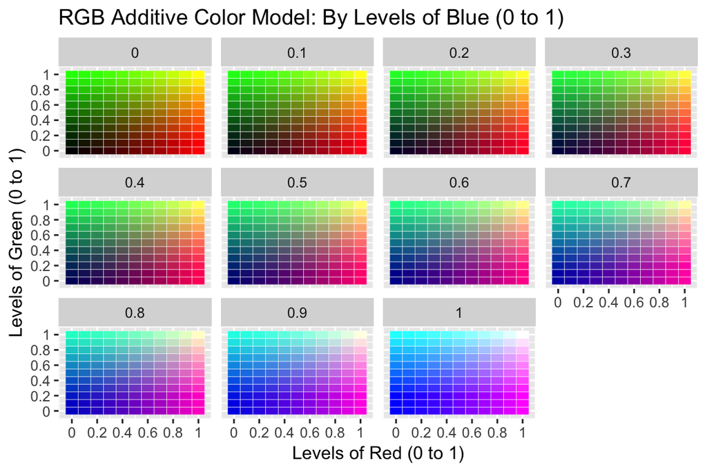

```r
expand.grid(r = seq(0, 1, 0.1), g = seq(0, 1, 0.1), b = seq(0, 1, 0.1)) %>%
  ggplot() + facet_wrap( ~ b) +
  scale_x_continuous(name = "Levels of Red (0 to 1)",
                     breaks = seq(0.05, 1.05, 0.2),
                     labels = seq (0, 1, 0.2)) +
  scale_y_continuous(name = "Levels of Green (0 to 1)",
                     breaks = seq(0.05, 1.05, 0.2),
                     labels = seq(0, 1, 0.2)) +
  scale_fill_identity() +
  geom_rect(aes(xmin = r, xmax = r + resolution(r),
                ymin = g, ymax = g + resolution(g),
                fill = rgb(r, g, b)),
            color = "white", size = 0.1) +
  ggtitle("RGB Additive Color Model: By Levels of Blue (0 to 1)")
```

- `stringr` for string manipulation. A cheatsheet is available [here](http://edrub.in/CheatSheets/cheatSheetStringr.pdf). If you do want to work on string variables a lot, for example to do web scrapping, then you should learn about [regular expressions](https://www.rstudio.com/wp-content/uploads/2016/09/RegExCheatsheet.pdf).
- `readr` to read in data. A cheatsheet is provided [here](https://ugoproto.github.io/ugo_r_doc/data-import.pdf).

In addition to the `tidyverse` collection of R packages, I also use the following packages:

- `lubridate` for working with dates (very useful in macroeconomics !). A cheatsheet is provided [here](https://evoldyn.gitlab.io/evomics-2018/ref-sheets/R_lubridate.pdf).

## Other Packages

Here are other potentially useful packages:

- `tidytext` for analyzing text with the `tidyverse` tools. A great introduction to this package is provided [here](https://www.tidytextmining.com/tidytext.html).
- `bookdown` as a great complement to R-markdown, in order to write more advanced documents. A great introduction is also provided [here](https://bookdown.org/yihui/bookdown/).